# Netflix filmovi

2023-12-16

```r
data2 <- read_csv("NetflixOriginals.csv")
data_genre_sep <- separate(data2,Genre,into = c("Genre_1","Genre_2","Genre_3","Genre_4"),sep = "/",remove = T)
data_genre_sep
```

```
## # A tibble: 584 × 9
##    Title  Genre_1 Genre_2 Genre_3 Genre_4 Premiere Runtime `IMDB Score` Language
##    <chr>  <chr>   <chr>   <chr>   <chr>   <chr>      <dbl>        <dbl> <chr>
##  1 Enter… Docume… <NA>    <NA>    <NA>    August …      58          2.5 English…
##  2 Dark … Thrill… <NA>    <NA>    <NA>    August …      81          2.6 Spanish
##  3 The A… Scienc… Drama   <NA>    <NA>    Decembe…      79          2.6 Italian
##  4 The O… Horror… <NA>    <NA>    <NA>    January…      94          3.2 English
##  5 Kaali… Mystery <NA>    <NA>    <NA>    October…      90          3.4 Hindi
##  6 Drive  Action  <NA>    <NA>    <NA>    Novembe…     147          3.5 Hindi
##  7 Leyla… Comedy  <NA>    <NA>    <NA>    Decembe…     112          3.7 Turkish
##  8 The L… Heist … Thrill… <NA>    <NA>    June 5,…     149          3.7 English
##  9 Parad… Musical Western Fantasy <NA>    March 2…      73          3.9 English
## 10 Sarda… Comedy  <NA>    <NA>    <NA>    May 18,…     139          4.1 Hindi
## # ℹ 574 more rows
```

```r
data1 <- data_genre_sep

genre_1_runtime <-data1[,c("Genre_1","Language")]
genre_2_runtime <-data1[,c("Genre_2","Language")]
genre_3_runtime <-data1[,c("Genre_3","Language")]
genre_4_runtime <-data1[,c("Genre_4","Language")]

colnames(genre_1_runtime)[1] <- "Genre"
colnames(genre_2_runtime)[1] <- "Genre"
colnames(genre_3_runtime)[1] <- "Genre"
colnames(genre_4_runtime)[1] <- "Genre"

genre_language <- rbind(genre_1_runtime,genre_2_runtime,genre_3_runtime,genre_4_runtime)
genre_language
```

```
## # A tibble: 2,336 × 2
##    Genre           Language
##    <chr>           <chr>
##  1 Documentary     English/Japanese
##  2 Thriller        Spanish
##  3 Science fiction Italian
##  4 Horror thriller English
##  5 Mystery         Hindi
##  6 Action          Hindi
##  7 Comedy          Turkish
##  8 Heist film      English
##  9 Musical         English
## 10 Comedy          Hindi
## # ℹ 2,326 more rows
```

```r
genre_language$Genre <- str_trim(genre_language$Genre)

genre_language$Genre[genre_language$Genre=="Musicial"] <- "Musical"
genre_language$Genre[genre_language$Genre=="Action thriller"] <- "Action-thriller"
genre_language$Genre[genre_language$Genre=="Heist film"] <- "Heist"
genre_language$Genre[genre_language$Genre=="Romance drama"] <- "Romantic drama"
genre_language$Genre[genre_language$Genre=="Romantic teen drama"] <- "Romantic teenage drama"
genre_language$Genre[genre_language$Genre=="Science Fiction"] <- "Science fiction"
genre_language$Genre[genre_language$Genre %in% c("Action","Action comedy","Action-adventure","Action-thriller")] <- "Action"
genre_language$Genre[genre_language$Genre %in% c("Adventure","Adventure-romance")] <- "Adventure"
genre_language$Genre[genre_language$Genre %in% c("Animated musical comedy","Animation")] <- "Animation"
genre_language$Genre[genre_language$Genre %in% c("Black comedy","Comedy","Comedy horror","Comedy mystery","Comedy-drama","Coming-of-age comedy-drama","Dark comedy","Dance comedy")] <- "Comedy"
genre_language$Genre[genre_language$Genre %in% c("Christian musical","Christmas","Christmas comedy","Christmas musical")] <- "Christmas"
genre_language$Genre[genre_language$Genre %in% c("Crime drama","Crime thriller")] <- "Crime"
genre_language$Genre[genre_language$Genre %in% c("Drama","Drama-Comedy","Supernatural drama")] <- "Drama"
genre_language$Genre[genre_language$Genre %in% c("Family","Family film")] <- "Family"
genre_language$Genre[genre_language$Genre %in% c("Historical drama","Historical-epic")] <- "Historical"
genre_language$Genre[genre_language$Genre %in% c("Horror-thriller","Horror thriller","Horror comedy","Horror anthology","Horror")] <- "Horror"
genre_language$Genre[genre_language$Genre %in% c("Musical","Musical comedy")] <- "Musical"
genre_language$Genre[genre_language$Genre %in% c("Political thriller","Psychological thriller","Psychological thriller drama")] <- "Psychological"
genre_language$Genre[genre_language$Genre %in% c("Romantic comedy","Romantic comedy-drama","Romantic drama","Romance","Romantic teenage drama","Romantic thriller")] <- "Romance"
genre_language$Genre[genre_language$Genre %in% c("Science fiction adventure","Science fiction thriller")] <- "Science fiction"
genre_language$Genre[genre_language$Genre %in% c("Sports film","Sports-drama")] <- "Sports"
genre_language$Genre[genre_language$Genre %in% c("Spy thriller","Thriller")] <- "Thriller"
genre_language$Genre[genre_language$Genre %in% c("Superhero","Superhero-Comedy")] <- "Superhero"
genre_language$Genre[genre_language$Genre %in% c("Teen comedy horror","Teen comedy-drama")] <- "Teen"
genre_language$Genre[genre_language$Genre %in% c("Variety Show","Variety show")] <- "Variety"
genre_language$Genre[genre_language$Genre %in% c("War","War drama","War-Comedy")] <- "War"
```

**PRVO PITANJE**

```r
#pojednostavljamo jezike
genre_language$Language[genre_language$Language=="English/Japanese"] <- "Japanese"
genre_language$Language[genre_language$Language=="English/Spanish"] <- "Spanish"
genre_language$Language[genre_language$Language=="Spanish/Basque"] <- "Spanish"
genre_language$Language[genre_language$Language=="Spanish/Catalan"] <- "Spanish"
genre_language$Language[genre_language$Language=="English/Swedish"] <- "Swedish"
genre_language$Language[genre_language$Language=="English/Taiwanese/Mandarin"] <- "English"
genre_language$Language[genre_language$Language=="Thia/English"] <- "English"
genre_language$Language[genre_language$Language=="English/Mandarin"] <- "Mandarin"
genre_language$Language[genre_language$Language=="Khmer/English/French"] <- "French"
genre_language$Language[genre_language$Language=="English/Hindi"] <- "Hindi"
genre_language$Language[genre_language$Language=="Spanish/English"] <- "Spanish"
genre_language$Language[genre_language$Language=="English/Korean"] <- "Korean"
genre_language$Language[genre_language$Language=="English/Arabic"] <- "Arabic"
genre_language$Language[genre_language$Language=="English/Russian"] <- "Russian"
genre_language$Language[genre_language$Language=="English/Akan"] <- "English"
genre_language$Language[genre_language$Language=="English/Ukranian/Russian"] <- "Russian"
genre_language
```

```
## # A tibble: 2,336 × 2
##    Genre           Language
##    <chr>           <chr>
##  1 Documentary     Japanese
##  2 Thriller        Spanish
##  3 Science fiction Italian
##  4 Horror          English
##  5 Mystery         Hindi
##  6 Action          Hindi
##  7 Comedy          Turkish
##  8 Heist           English
##  9 Musical         English
## 10 Comedy          Hindi
## # ℹ 2,326 more rows
```

```r
genre_language <- genre_language %>% filter_all(all_vars(. != "NA"))
genre_language
```

```
## # A tibble: 643 × 2
##    Genre           Language
##    <chr>           <chr>
##  1 Documentary     Japanese
##  2 Thriller        Spanish
##  3 Science fiction Italian
##  4 Horror          English
##  5 Mystery         Hindi
##  6 Action          Hindi
##  7 Comedy          Turkish
##  8 Heist           English
##  9 Musical         English
## 10 Comedy          Hindi
## # ℹ 633 more rows
```

```r
table(genre_language$Language) %>% sort()
```

```
##
##     Arabic    Bengali   Georgian      Malay  Norwegian      Tamil   Filipino
##          1          1          1          1          1          1          2
##   Mandarin    Russian    Swedish       Thai      Dutch    Marathi     Polish
##          2          2          2          2          3          3          3
##     German    Turkish     Korean Indonesian   Japanese Portuguese    Italian
##          5          5          7          9         11         12         15
##     French      Hindi    Spanish    English
##         21         36         39        458
```

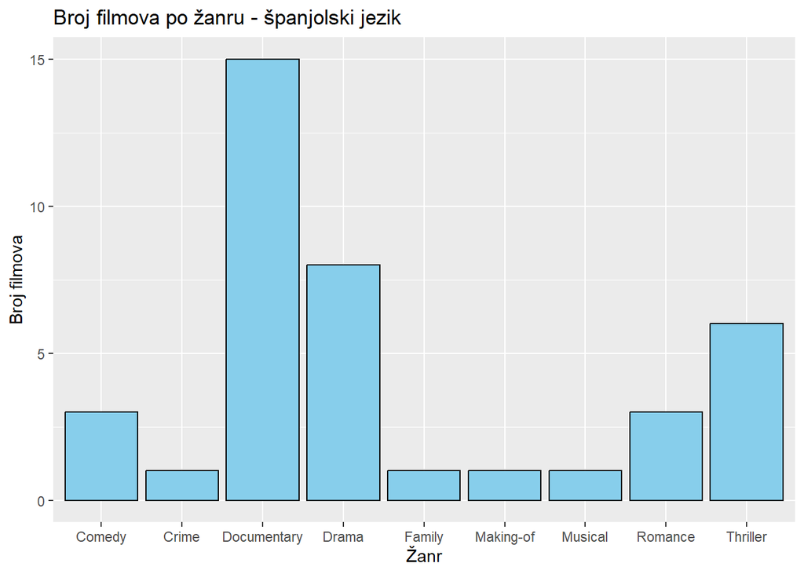

```r
#uzimamo u obzir top 10 zastupljenih jezika
data_Portugese <- subset(genre_language,  Language== "Portuguese")
data_Italian <- subset(genre_language,  Language== "Italian")
data_French <- subset(genre_language,  Language== "French")
data_Hindi <- subset(genre_language,  Language== "Hindi")
data_Spanish <- subset(genre_language,  Language== "Spanish")
data_English <- subset(genre_language,  Language== "English")
data_Indonesian <- subset(genre_language,  Language== "Indonesian")
data_Japanese <- subset(genre_language,  Language== "Japanese")
data_Korean <- subset(genre_language,  Language== "Korean")
data_Turkish <- subset(genre_language,  Language== "Turkish")

data_Portugese$Genre <- factor(data_Portugese$Genre)
data_Italian$Genre <- factor(data_Italian$Genre)
data_French$Genre <- factor(data_French$Genre)
data_Hindi$Genre <- factor(data_Hindi$Genre)
data_Spanish$Genre <- factor(data_Spanish$Genre)
data_English$Genre <- factor(data_English$Genre)
data_Indonesian$Genre <- factor(data_Indonesian$Genre)
data_Japanese$Genre <- factor(data_Japanese$Genre)
data_Korean$Genre <- factor(data_Korean$Genre)
data_Turkish$Genre <- factor(data_Turkish$Genre)


ggplot(data_Spanish, aes(x = Genre)) +
  geom_bar(fill = "skyblue", color = "black") +
  labs(title = "Broj filmova po žanru - španjolski jezik", x = "Žanr", y = "Broj filmova")
```

```r
table(data_English$Genre)
```

```
##
##                     Action                  Adventure
##                         15                          8
##                  Aftershow                  Animation
##                          6                         17
##                      Anime               Biographical
##                          1                          1
##                     Biopic                  Christmas
##                          8                          6
##                     Comedy               Concert Film
##                         56                          6
##                      Crime                Documentary
##                          7                        121
##                      Drama                     Family
##                         41                          6
##                    Fantasy                      Heist
##                          3                          3
## Hidden-camera prank comedy                 Historical
##                          1                          2
##                    Holiday                     Horror
##                          1                         14
##                  Interview                  Making-of
##                          6                          1
##          Mentalism special               Mockumentary
##                          1                          2
##                    Musical                    Mystery
##                          9                          2
##               One-man show              Psychological
##                          3                          5
##       Psychological horror                    Romance
##                          1                         36
##                     Satire            Science fiction
##                          1                         14
##                      Short                     Sports
##                          7                          3
##                Stop Motion                  Superhero
##                          1                          5
##                       Teen                   Thriller
##                          2                         21
##              Urban fantasy                    Variety
##                          1                          5
##                        War                    Western
##                          5                          3
##                     Zombie
##                          1
```

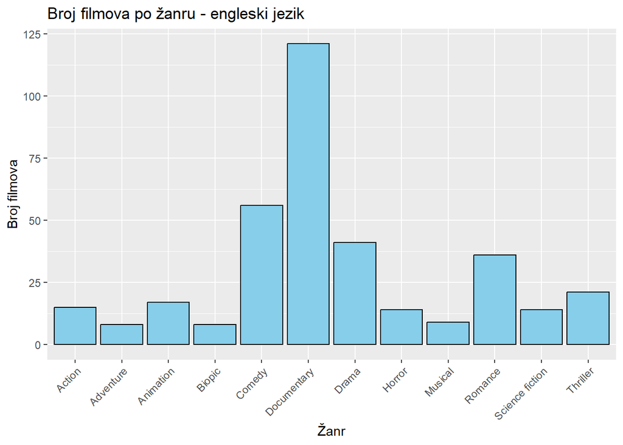

```r
# Brojanje pojavljivanja žanrova
genre_counts <- data_English %>% count(Genre)

# Filtriranje žanrova koji se pojavljuju 8 ili više puta
data_English_filtered <- data_English %>%
  filter(Genre %in% genre_counts$Genre[genre_counts$n >= 8])


ggplot(data_English_filtered, aes(x = Genre)) +
  geom_bar(fill = "skyblue", color = "black") +
  labs(title = "Broj filmova po žanru - engleski jezik", x = "Žanr", y = "Broj filmova")+
  theme(axis.text.x = element_text(angle=45,hjust = 1))
```

```r
# Navedite žanrove koje želite ukloniti
jezici_za_sadržavanje <- c("Portuguese", "Italian","French","Hindi","Spanish","English","Indonesian","Japanese","Korean","Turkish")

# Filtrirajte podatke tako da uklonite retke s određenim žanrovima
genre_language_filtered <- genre_language %>% filter(Language %in% jezici_za_sadržavanje)

genre_language_filtered
```

```
## # A tibble: 613 × 2
##    Genre           Language
##    <chr>           <chr>
##  1 Documentary     Japanese
##  2 Thriller        Spanish
##  3 Science fiction Italian
##  4 Horror          English
##  5 Mystery         Hindi
##  6 Action          Hindi
##  7 Comedy          Turkish
##  8 Heist           English
##  9 Musical         English
## 10 Comedy          Hindi
## # ℹ 603 more rows
```

```r
genre_language_filtered$Language <- factor(genre_language_filtered$Language)
```

Iz ove tablice možemo zaključiti da ne možemo koristiti Hi-kvadrat test jer preduvjet očekivane frekvencije nije bio zadovoljen (očekivana frekvencija mora biti veća od 5)

```r
# Kreiranje kontingencijske tablice
contingency_table <- table(genre_language_filtered$Genre, genre_language_filtered$Language)
contingency_table
```

```
##
##                              English French Hindi Indonesian Italian Japanese
##   Action                          15      2     1          1       0        0
##   Adventure                        8      0     0          0       0        0
##   Aftershow                        6      0     0          0       0        0
##   Animation                       17      0     0          0       0        0
##   Anime                            1      0     0          0       0        3
##   Anthology                        0      0     1          0       0        0
##   Biographical                     1      0     0          0       0        0
##   Biopic                           8      0     0          0       1        0
##   Christmas                        6      0     0          0       0        0
##   Comedy                          56      2     7          2       3        0
##   Concert Film                     6      0     0          0       0        0
##   Crime                            7      1     1          0       1        1
##   Documentary                    121      6     2          0       0        2
##   Drama                           41      3    13          3       5        1
##   Family                           6      0     0          0       0        0
##   Fantasy                          3      0     0          0       0        1
##   Heist                            3      0     0          0       0        0
##   Hidden-camera prank comedy       1      0     0          0       0        0
##   Historical                       2      0     0          0       0        0
##   Holiday                          1      0     0          0       0        0
##   Horror                          14      0     2          0       0        0
##   Interview                        6      0     0          0       0        0
##   Making-of                        1      0     0          0       0        0
##   Mentalism special                1      0     0          0       0        0
##   Mockumentary                     2      0     0          0       0        0
##   Musical                          9      0     0          0       0        0
##   Mystery                          2      0     1          0       0        0
##   One-man show                     3      0     0          0       0        0
##   Psychological                    5      0     0          0       0        1
##   Psychological horror             1      0     0          0       0        0
##   Romance                         36      3     3          3       3        0
##   Satire                           1      0     0          0       0        0
##   Science fiction                 14      1     0          0       1        2
##   Short                            7      0     0          0       0        0
##   Sports                           3      0     0          0       1        0
##   Stop Motion                      1      0     0          0       0        0
##   Superhero                        5      0     0          0       0        0
##   Teen                             2      0     0          0       0        0
```

[output cut: 37 more lines]

```
##   Psychological horror            0          0       0       0
##   Romance                         0          1       3       1
##   Satire                          0          0       0       0
##   Science fiction                 1          0       0       0
##   Short                           0          0       0       0
##   Sports                          0          0       0       0
##   Stop Motion                     0          0       0       0
##   Superhero                       0          0       0       0
##   Teen                            0          0       0       0
##   Thriller                        1          0       6       0
##   Urban fantasy                   0          0       0       0
##   Variety                         0          0       0       0
##   War                             0          0       0       0
##   Western                         0          1       0       0
##   Zombie                          0          0       0       0
```

Razlog korištenja Fisherovog testa je nemogućnost korištenja Hi-kvadrat testa Postavljanje hipoteza: H0: ne postoji povezanost između Žanra i Područja H1: postoji povezanost između Žanra i Područja alpha=0.05

```r
fisher_test <- fisher.test(contingency_table, simulate.p.value = TRUE)
print(fisher_test)
```

```
##
##  Fisher's Exact Test for Count Data with simulated p-value (based on
##  2000 replicates)
##
## data:  contingency_table
## p-value = 0.4713
## alternative hypothesis: two.sided
```

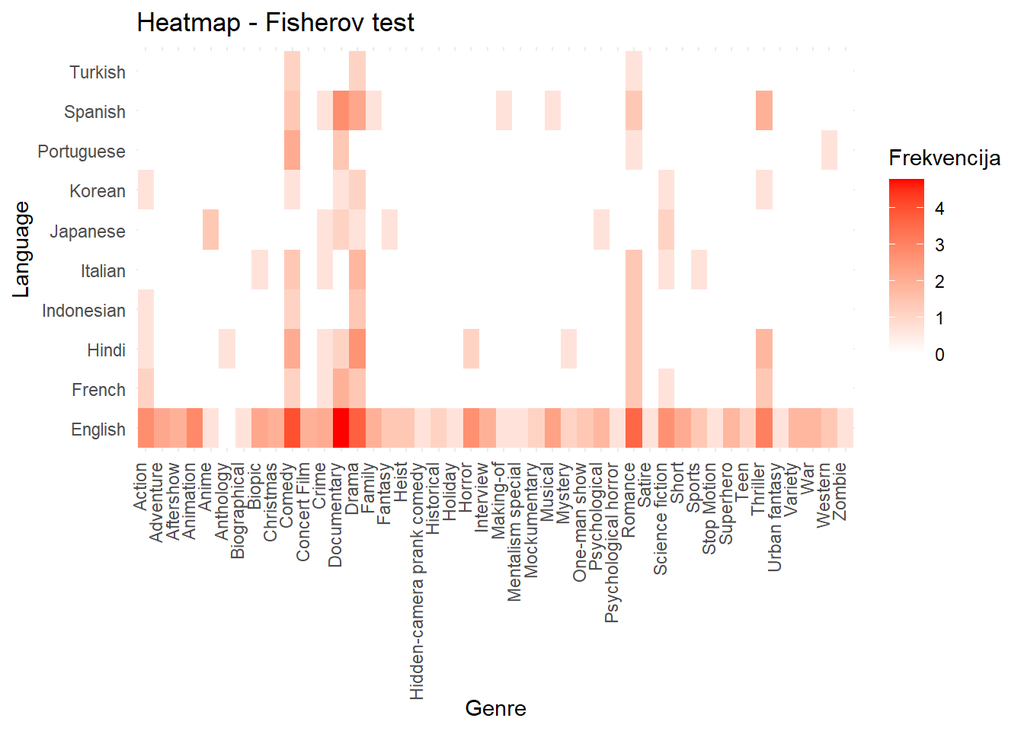

```r
ggplot(as.data.frame.table(contingency_table), aes(x = Var1, y = Var2, fill = log(Freq + 1))) +
  geom_tile() +
  scale_fill_gradient(low = "white", high = "red") +
  labs(title = "Heatmap - Fisherov test" ,x = "Genre", y = "Language",fill="Frekvencija") +
  theme_minimal() +
  theme(axis.text.x = element_text(angle = 90, hjust = 1, vjust = -0.02))
```

**DRUGO PITANJE**

```r
data2 <- read_csv("NetflixOriginals.csv")
```

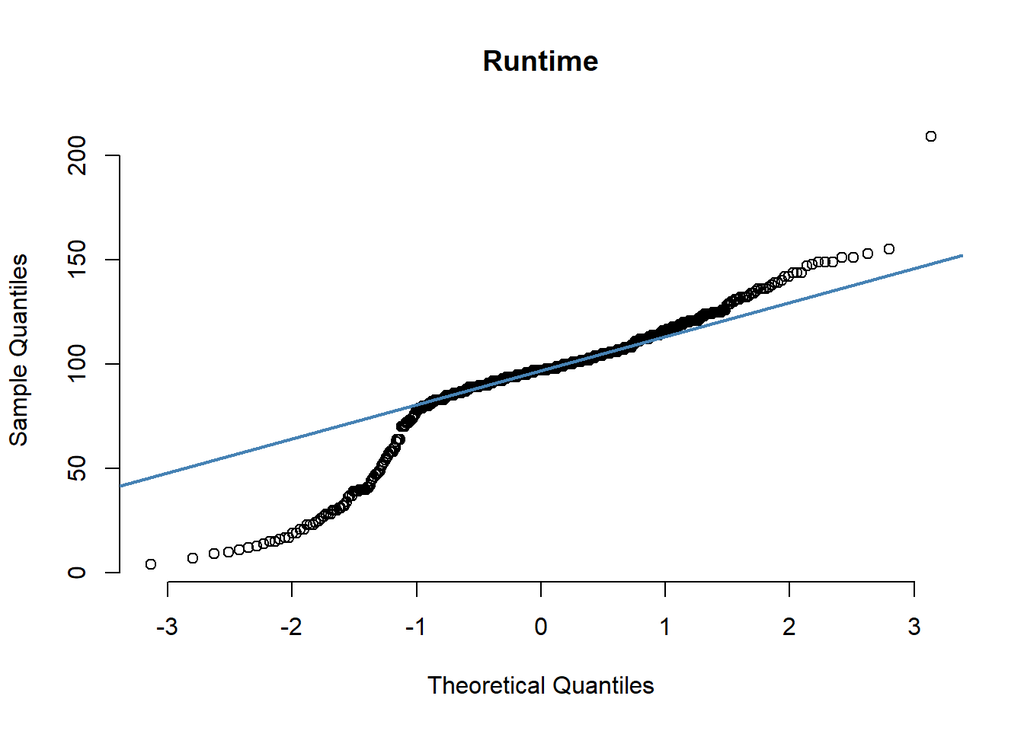

```r
qqnorm(data1$Runtime , pch = 1, frame = FALSE,main='Runtime'); qqline(data1$Runtime , col = "steelblue", lwd = 2)
```

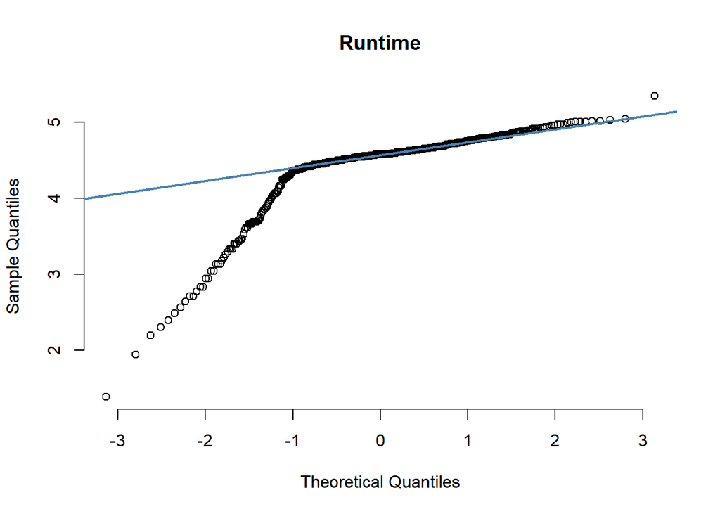

```r
qqnorm(log(data1$Runtime) , pch = 1, frame = FALSE,main='Runtime'); qqline(log(data1$Runtime) , col = "steelblue", lwd = 2)
```

Graf ukazuje na to na Runtime varijabla ima donekle normalnu razdiobu, sa time da imamo vecu devijaciju od normalne razdiobe u lijevom repu a manju devjaciju u desom repu

Kad primjenimo logaritam uočavamo da se situacija poboljšava u desnom repu tj da nestaje devijacija, no lijevi rep dobija vecu devijaciju

```r
#mozemo gledati više žanrova kao da je svaki svoj stupac ili budu svi u jednom stupcu pa da trazimo u tom stringu odredeni žanr
data_genre_sep <- separate(data2,Genre,into = c("Genre_1","Genre_2","Genre_3","Genre_4"),sep = "/",remove = T)
```

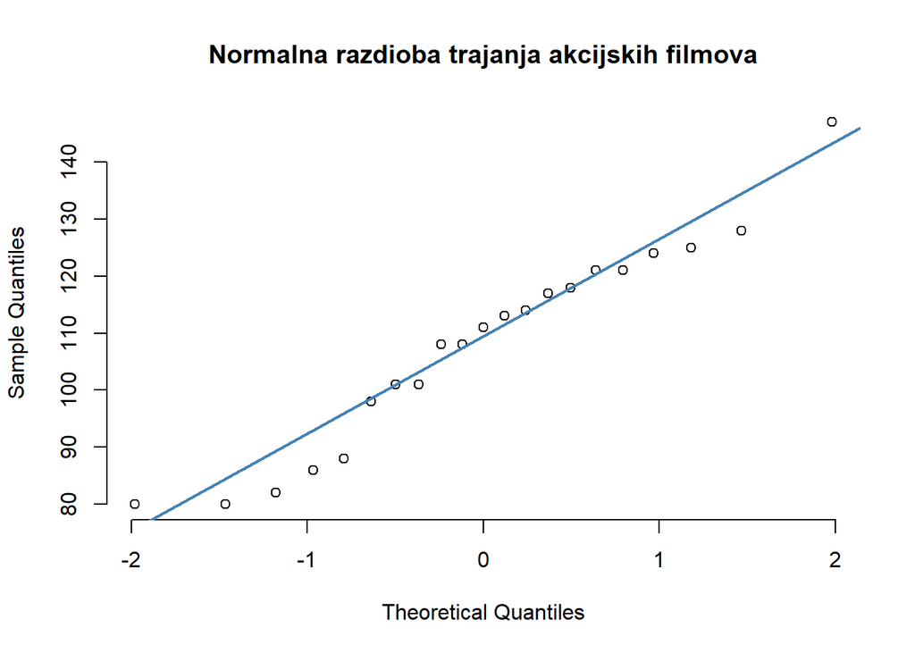

```r
data1 <- data_genre_sep

genre_1_runtime <-data1[,c("Genre_1","Runtime")]
genre_2_runtime <-data1[,c("Genre_2","Runtime")]
genre_3_runtime <-data1[,c("Genre_3","Runtime")]
genre_4_runtime <-data1[,c("Genre_4","Runtime")]

colnames(genre_1_runtime)[1] <- "Genre"
colnames(genre_2_runtime)[1] <- "Genre"
colnames(genre_3_runtime)[1] <- "Genre"
colnames(genre_4_runtime)[1] <- "Genre"

genre_runtime <- rbind(genre_1_runtime,genre_2_runtime,genre_3_runtime,genre_4_runtime)
genre_runtime$Genre <- str_trim(genre_runtime$Genre)

genre_runtime$Genre[genre_runtime$Genre=="Musicial"] <- "Musical"
genre_runtime$Genre[genre_runtime$Genre=="Action thriller"] <- "Action-thriller"
genre_runtime$Genre[genre_runtime$Genre=="Heist film"] <- "Heist"
genre_runtime$Genre[genre_runtime$Genre=="Romance drama"] <- "Romantic drama"
genre_runtime$Genre[genre_runtime$Genre=="Romantic teen drama"] <- "Romantic teenage drama"
genre_runtime$Genre[genre_runtime$Genre=="Science Fiction"] <- "Science fiction"
genre_runtime$Genre[genre_runtime$Genre %in% c("Action","Action comedy","Action-adventure","Action-thriller")] <- "Action"
genre_runtime$Genre[genre_runtime$Genre %in% c("Adventure","Adventure-romance")] <- "Adventure"
genre_runtime$Genre[genre_runtime$Genre %in% c("Animated musical comedy","Animation")] <- "Animation"
genre_runtime$Genre[genre_runtime$Genre %in% c("Black comedy","Comedy","Comedy horror","Comedy mystery","Comedy-drama","Coming-of-age comedy-drama","Dark comedy","Dance comedy")] <- "Comedy"
genre_runtime$Genre[genre_runtime$Genre %in% c("Christian musical","Christmas","Christmas comedy","Christmas musical")] <- "Christmas"
genre_runtime$Genre[genre_runtime$Genre %in% c("Crime drama","Crime thriller")] <- "Crime"
genre_runtime$Genre[genre_runtime$Genre %in% c("Drama","Drama-Comedy","Supernatural drama")] <- "Drama"
genre_runtime$Genre[genre_runtime$Genre %in% c("Family","Family film")] <- "Family"
genre_runtime$Genre[genre_runtime$Genre %in% c("Historical drama","Historical-epic")] <- "Historical"
genre_runtime$Genre[genre_runtime$Genre %in% c("Horror-thriller","Horror thriller","Horror comedy","Horror anthology","Horror")] <- "Horror"
genre_runtime$Genre[genre_runtime$Genre %in% c("Musical","Musical comedy")] <- "Musical"
genre_runtime$Genre[genre_runtime$Genre %in% c("Political thriller","Psychological thriller","Psychological thriller drama")] <- "Psychological"
genre_runtime$Genre[genre_runtime$Genre %in% c("Romantic comedy","Romantic comedy-drama","Romantic drama","Romance","Romantic teenage drama","Romantic thriller")] <- "Romance"
genre_runtime$Genre[genre_runtime$Genre %in% c("Science fiction adventure","Science fiction thriller")] <- "Science fiction"
genre_runtime$Genre[genre_runtime$Genre %in% c("Sports film","Sports-drama")] <- "Sports"
genre_runtime$Genre[genre_runtime$Genre %in% c("Spy thriller","Thriller")] <- "Thriller"
genre_runtime$Genre[genre_runtime$Genre %in% c("Superhero","Superhero-Comedy")] <- "Superhero"
genre_runtime$Genre[genre_runtime$Genre %in% c("Teen comedy horror","Teen comedy-drama")] <- "Teen"
genre_runtime$Genre[genre_runtime$Genre %in% c("Variety Show","Variety show")] <- "Variety"
genre_runtime$Genre[genre_runtime$Genre %in% c("War","War drama","War-Comedy")] <- "War"

genre_runtime <- na.omit(genre_runtime)



qqnorm(genre_runtime$Runtime[genre_runtime$Genre=="Action"] , pch = 1, frame = FALSE,main='Normalna razdioba trajanja akcijskih filmova');qqline(genre_runtime$Runtime[genre_runtime$Genre=="Action"] , col = "steelblue", lwd = 2)
```

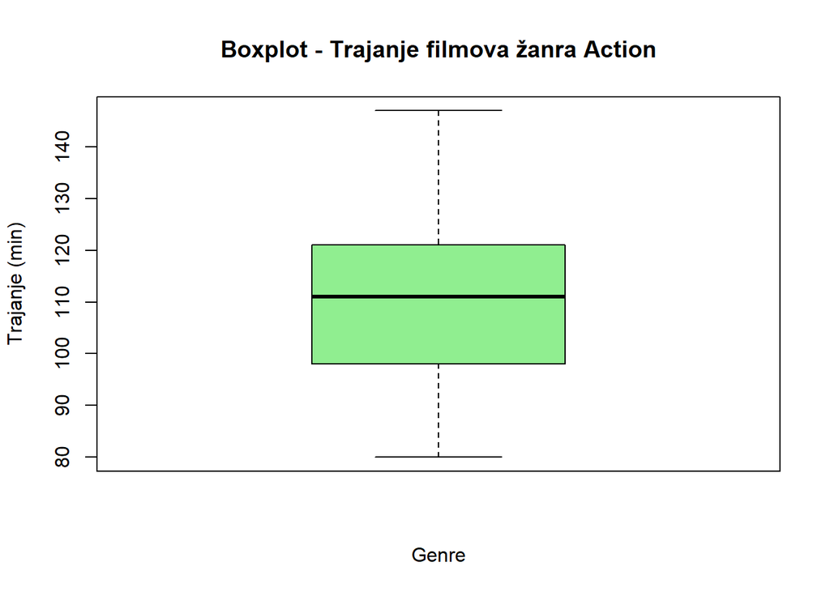

```r
boxplot(Runtime ~ Genre, data = genre_runtime[genre_runtime$Genre=="Action",], col = "lightgreen", main = "Boxplot - Trajanje filmova žanra Action", ylab = "Trajanje (min)")
```

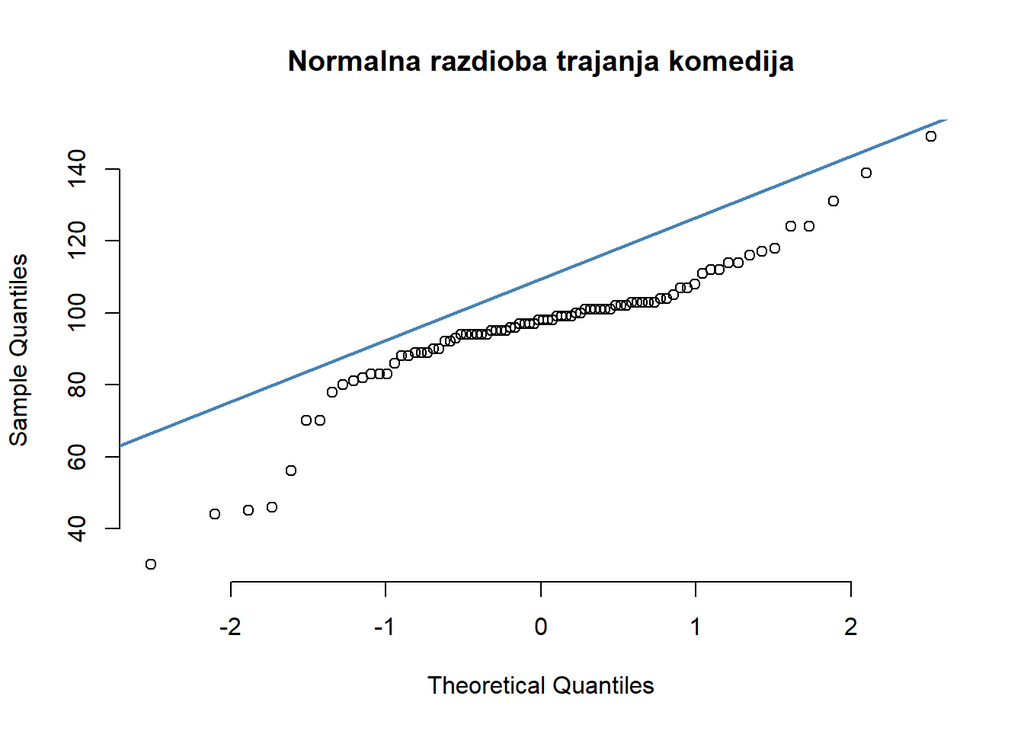

```r
qqnorm(genre_runtime$Runtime[genre_runtime$Genre=="Comedy"] , pch = 1, frame = FALSE,main='Normalna razdioba trajanja komedija');qqline(genre_runtime$Runtime[genre_runtime$Genre=="Action"] , col = "steelblue", lwd = 2)
```

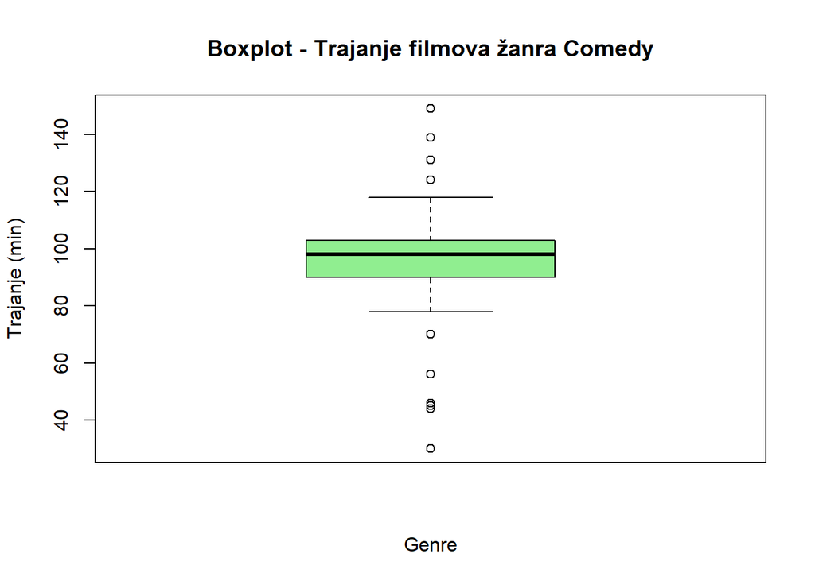

```r
boxplot(Runtime ~ Genre, data = genre_runtime[genre_runtime$Genre=="Comedy",], col = "lightgreen", main = "Boxplot - Trajanje filmova žanra Comedy", ylab = "Trajanje (min)")
```

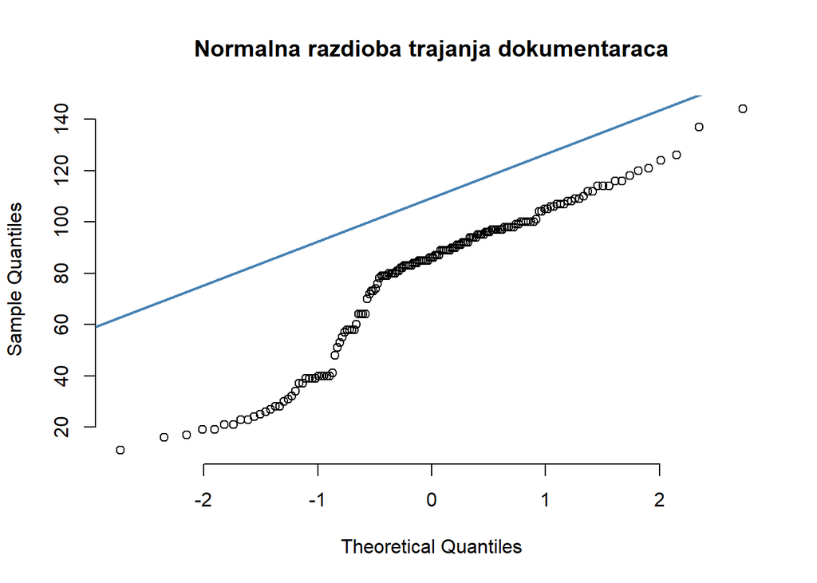

```r
qqnorm(genre_runtime$Runtime[genre_runtime$Genre=="Documentary"] , pch = 1, frame = FALSE,main='Normalna razdioba trajanja dokumentaraca');qqline(genre_runtime$Runtime[genre_runtime$Genre=="Action"] , col = "steelblue", lwd = 2)
```

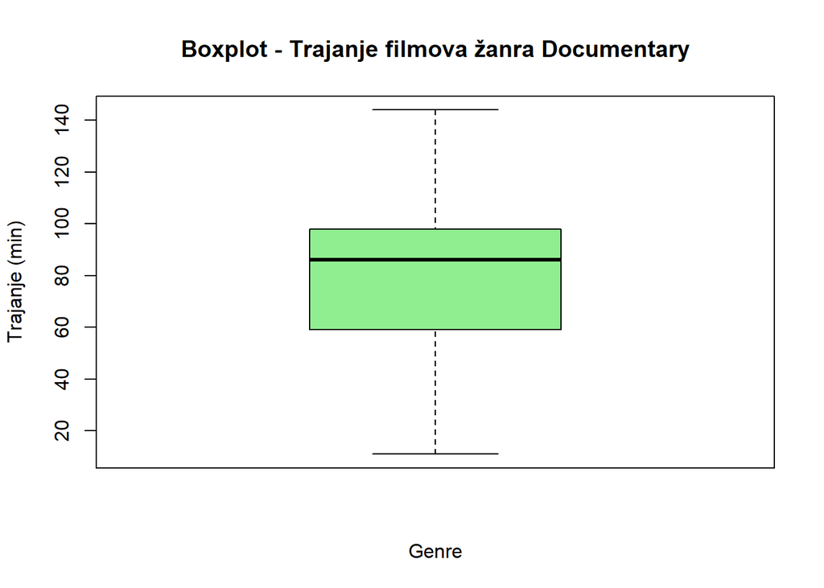

```r
boxplot(Runtime ~ Genre, data = genre_runtime[genre_runtime$Genre=="Documentary",], col = "lightgreen", main = "Boxplot - Trajanje filmova žanra Documentary", ylab = "Trajanje (min)")
```

[figure not shown]

```r
hist(genre_runtime$Runtime[genre_runtime$Genre=="Documentary"], col = "skyblue", main = "Histogram - Trajanje filmova žanra Action", xlab = "Trajanje (min)", ylab = "Broj filmova")
```

ANOVA test za testiranje odnosa Genre i Runtime H0: srednja vrijednost Runtime za sve Genre je jednaka H1: srednja vrijednost Runtime za sve Genre nije jednaka

```r
one.way <- aov(Runtime ~ Genre, data= genre_runtime)
summary(one.way)
```

```
##              Df Sum Sq Mean Sq F value Pr(>F)
## Genre        43 250006    5814   11.53 <2e-16 ***
## Residuals   599 301969     504
## ---
## Signif. codes:  0 '***' 0.001 '**' 0.01 '*' 0.05 '.' 0.1 ' ' 1
```

Mala vrijednost Pr(>F) (p-value) ukazuje na to da varijabla Genre ima stvaran utjecaj na RunTime varijablu, odnosno da žanr filma ima utjecaj na duljinu samog filma pa se time H0 pretpostavka odbacuje u korist H1.

Pet žanrova sa najduljom sredinom trajanja i pet žanrova sa najkraćom sredinom trajanja.

```r
genre_runtime %>% group_by(Genre) %>% summarise(mean(Runtime))->genre_runtime_mean
rbind(slice_max(genre_runtime_mean,`mean(Runtime)`,n=5),slice_min(genre_runtime_mean,`mean(Runtime)`,n=5))
```

```
## # A tibble: 10 × 2
##    Genre       `mean(Runtime)`
##    <chr>                 <dbl>
##  1 Anthology             149
##  2 Zombie                148
##  3 Heist                 131.
##  4 Historical            130.
##  5 War                   127.
##  6 Short                  11.3
##  7 Aftershow              23.7
##  8 Interview              23.7
##  9 Stop Motion            42
## 10 Making-of              42.5
```

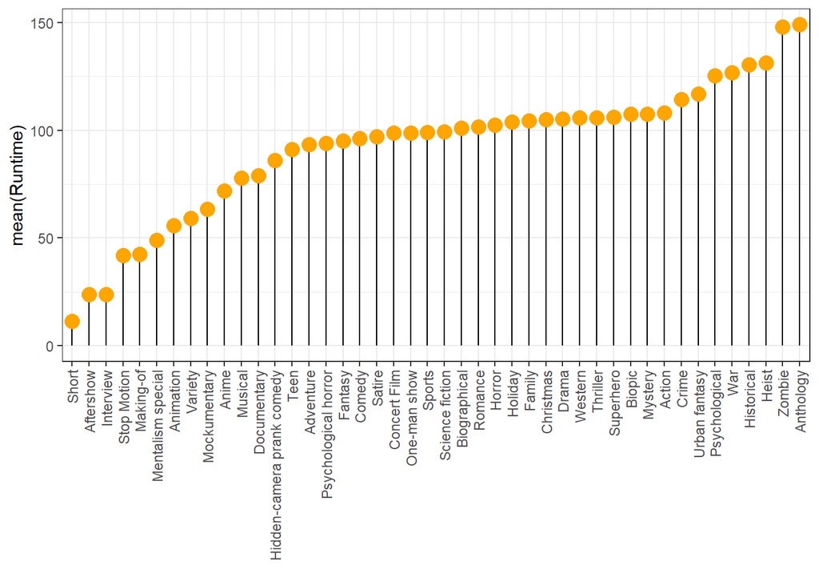

```r
library(ggplot2)
library(dplyr)

# Assuming your data frame is named 'your_data_frame'
genre_runtime_mean %>%
  arrange(`mean(Runtime)`) %>%
  mutate(Genre = factor(Genre, levels = unique(Genre))) %>%
  ggplot(aes(x = Genre, y = `mean(Runtime)`)) +
    geom_segment(aes(xend = Genre, yend = 0)) +
    geom_point(size = 4, color = "orange") +
    theme_bw() +
    xlab("")+
    theme(axis.text.x = element_text(angle = 90, vjust = 0.5, hjust = 1))
```

**TRECE PITANJE**

```r
data3 <- data2


data3$Year <- sub(".*?(\\d{4}).*", "\\1", data3$Premiere)

score_year <- data3[, c("IMDB Score", "Year")]

score_year$Year <- as.numeric(score_year$Year)

summary(score_year)
```

```
##    IMDB Score         Year
##  Min.   :2.500   Min.   :2014
##  1st Qu.:5.700   1st Qu.:2018
##  Median :6.350   Median :2019
##  Mean   :6.272   Mean   :2019
##  3rd Qu.:7.000   3rd Qu.:2020
##  Max.   :9.000   Max.   :2021
```

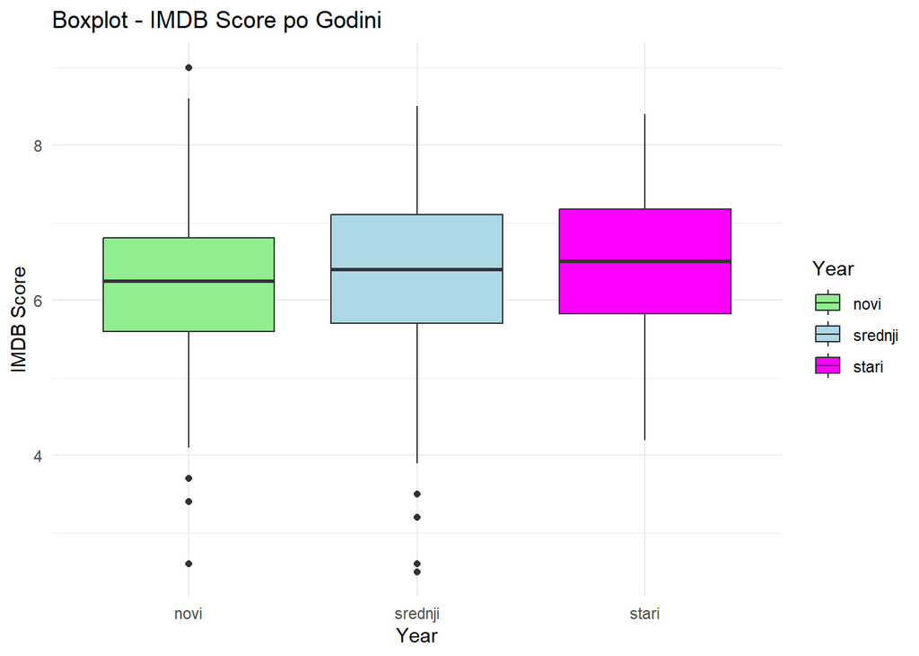

```r
score_year <- mutate(score_year, Year = ifelse(Year %in% c(2014,2015,2016,2017), "stari", as.character(Year)))
score_year <- mutate(score_year, Year = ifelse(Year %in% c(2018, 2019), "srednji", as.character(Year)))
score_year <- mutate(score_year, Year = ifelse(Year %in% c(2020, 2021), "novi", as.character(Year)))

score_year$Year <- as.factor(score_year$Year)



ggplot(score_year, aes(x = Year, y = `IMDB Score`, fill = Year)) +
  geom_boxplot() +
  labs(title = "Boxplot - IMDB Score po Godini", y = "IMDB Score") +
  scale_fill_manual(values = c("srednji" = "lightblue", "novi" = "lightgreen", "stari" = "magenta")) +
  theme_minimal()
```

ANOVA test za testiranje odnosa Razdoblja i IMDB Scorea H0: srednja vrijednost IMDB Scorea za sva Razdoblja je jednaka H1: srednja vrijednost IMDB Scorea za sva Razdoblja nije jednaka alfa = 0.05

```r
# Izvršavanje ANOVA analize
anova_result <- aov(`IMDB Score` ~ Year, data = score_year)

# Ispisivanje rezultata
summary(anova_result)
```

```
##              Df Sum Sq Mean Sq F value Pr(>F)
## Year          2    8.7   4.342   4.584 0.0106 *
## Residuals   581  550.4   0.947
## ---
## Signif. codes:  0 '***' 0.001 '**' 0.01 '*' 0.05 '.' 0.1 ' ' 1
```

P-vrijednost manja od 0.05 sugerira da postoji statistički značajna razlika između godina u odnosu na IMDB Score. Ova razlika nije nužno velika, ali je statistički značajna. Možemo odbaciti H0 u korist H1

```r
score_year %>% group_by(Year) %>% summarise(avgOcjena=mean(`IMDB Score`))->score_year_mean
score_year_mean
```

```
## # A tibble: 3 × 2
##   Year    avgOcjena
##   <fct>       <dbl>
## 1 novi         6.15
## 2 srednji      6.30
## 3 stari        6.49
```

**CETVRTO PITANJE**

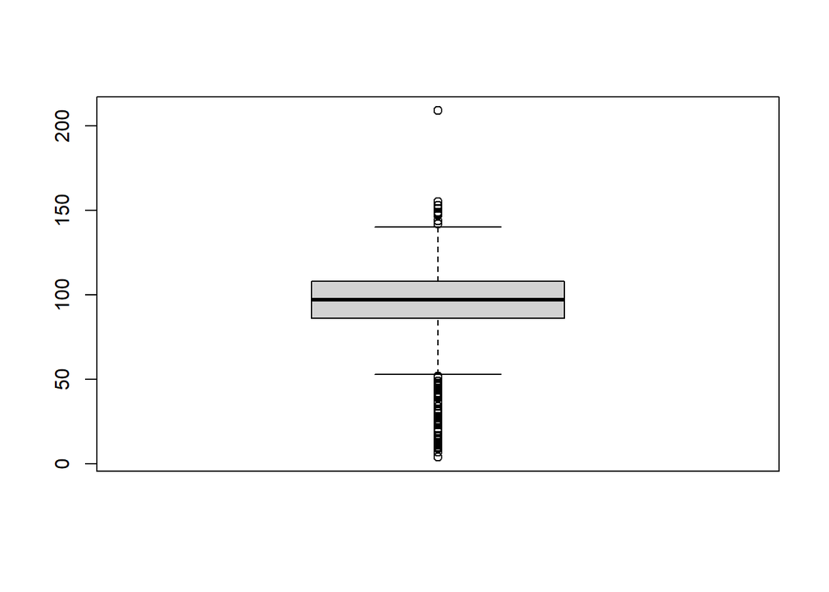

```r
data4 <- data2
data4 <- data4[,c("Runtime","IMDB Score")]


boxplot(data4$Runtime)
```

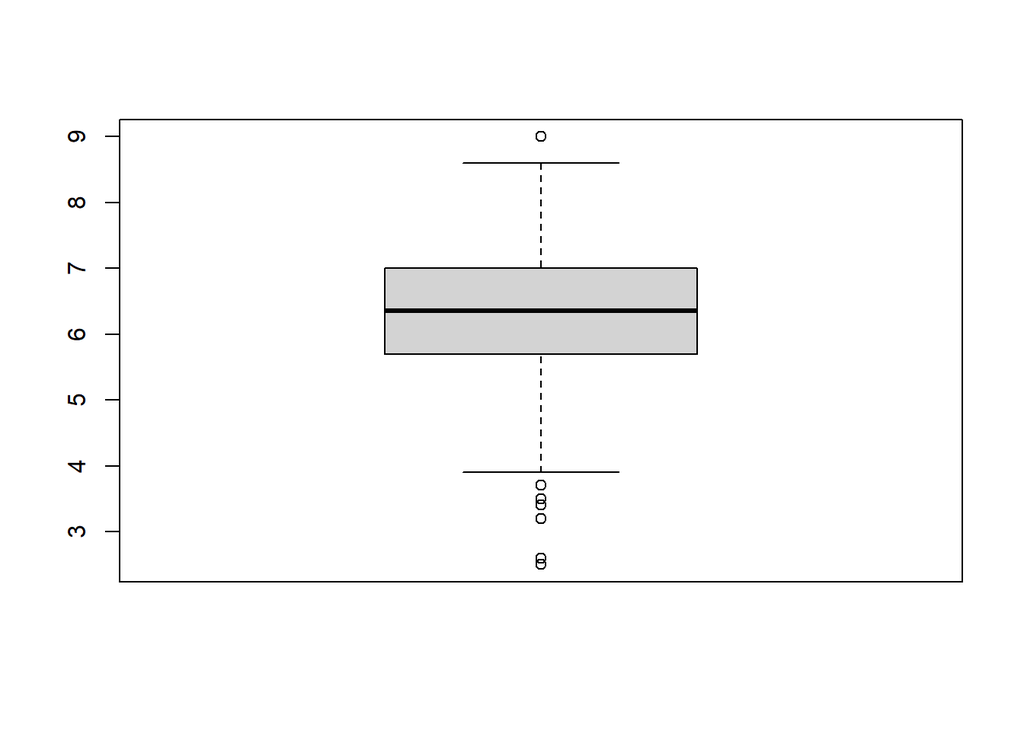

```r
boxplot(data4$`IMDB Score`)
```

```r
summary(data4$Runtime)
```

```
##    Min. 1st Qu.  Median    Mean 3rd Qu.    Max.
##    4.00   86.00   97.00   93.58  108.00  209.00
```

```r
lmOcjene = lm(`IMDB Score`~Runtime, data = data4) #Create the linear regression
summary(lmOcjene) #Review the results
```

```
##
## Call:
## lm(formula = `IMDB Score` ~ Runtime, data = data4)
##
## Residuals:
##     Min      1Q  Median      3Q     Max
## -3.8231 -0.5783  0.0729  0.6842  2.7130
##
## Coefficients:
##              Estimate Std. Error t value Pr(>|t|)
## (Intercept)  6.406737   0.142588  44.932   <2e-16 ***
## Runtime     -0.001443   0.001461  -0.987    0.324
## ---
## Signif. codes:  0 '***' 0.001 '**' 0.01 '*' 0.05 '.' 0.1 ' ' 1
##
## Residual standard error: 0.9793 on 582 degrees of freedom
## Multiple R-squared:  0.001673,   Adjusted R-squared:  -4.283e-05
## F-statistic: 0.975 on 1 and 582 DF,  p-value: 0.3238
```

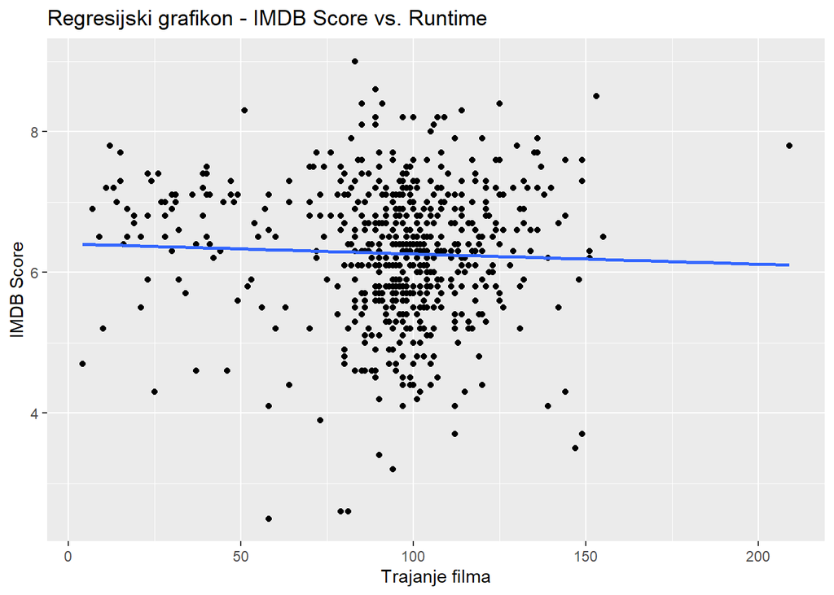

```r
ggplot(data4, aes(x = Runtime, y = `IMDB Score`)) +
  geom_point() +
  geom_smooth(method = "lm", se = FALSE) +
  labs(title = "Regresijski grafikon - IMDB Score vs. Runtime",
       x = "Trajanje filma", y = "IMDB Score")
```

Ako uzmemo u obzir sve filmove, vidimo blagi negativni trend u odnosu Ocjene i Duljine

```r
# Izračun kvantila
quantile_threshold <- quantile(data4$Runtime, probs = 0.67)  # Top 33%

# Izdvojeni retci s 'Runtime' u top 33%
selected_rows <- data4 %>%
  filter(Runtime >= quantile_threshold)

# Ispis odabranih redaka
print(selected_rows)
```

```
## # A tibble: 194 × 2
##    Runtime `IMDB Score`
##      <dbl>        <dbl>
##  1     147          3.5
##  2     112          3.7
##  3     149          3.7
##  4     139          4.1
##  5     112          4.1
##  6     144          4.3
##  7     115          4.3
##  8     120          4.4
##  9     105          4.4
## 10     107          4.5
## # ℹ 184 more rows
```

```r
lmOcjene = lm(`IMDB Score`~Runtime , data = selected_rows) #Model linearne regresije
summary(lmOcjene) #Summary rezultata modela
```

```
##
## Call:
## lm(formula = `IMDB Score` ~ Runtime, data = selected_rows)
##
## Residuals:
##      Min       1Q   Median       3Q      Max
## -3.11911 -0.52740  0.06366  0.66331  1.97104
##
## Coefficients:
##             Estimate Std. Error t value Pr(>|t|)
## (Intercept) 5.348563   0.582360   9.184   <2e-16 ***
## Runtime     0.008643   0.004876   1.773   0.0779 .
## ---
## Signif. codes:  0 '***' 0.001 '**' 0.01 '*' 0.05 '.' 0.1 ' ' 1
##
## Residual standard error: 0.9516 on 192 degrees of freedom
## Multiple R-squared:  0.0161, Adjusted R-squared:  0.01098
## F-statistic: 3.142 on 1 and 192 DF,  p-value: 0.07788
```

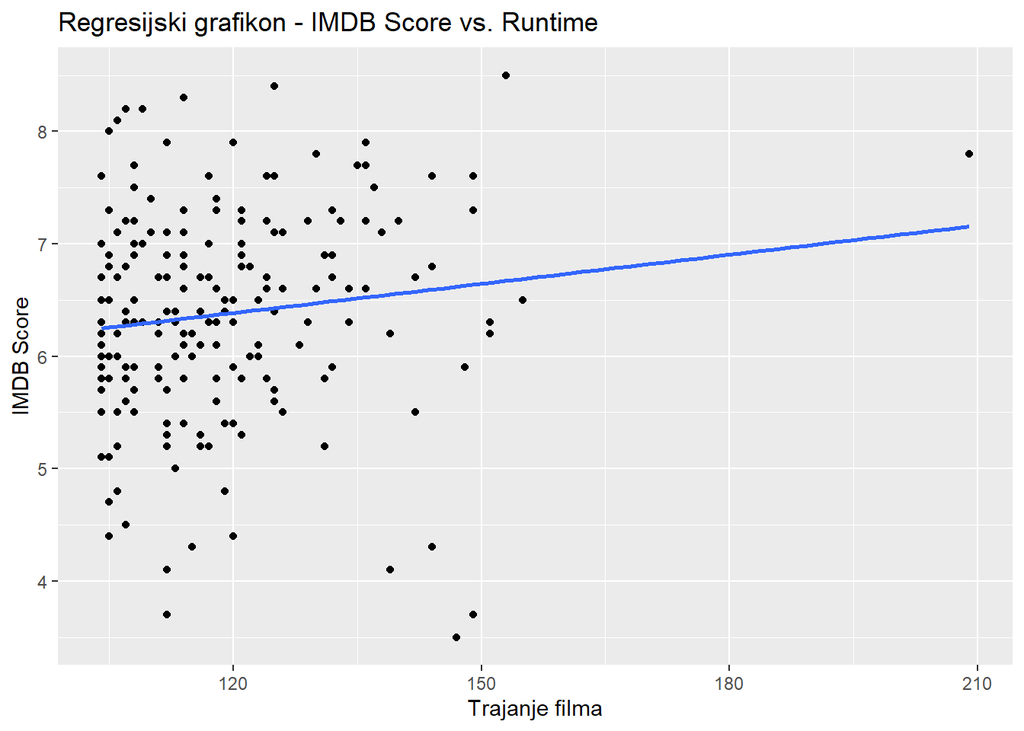

```r
ggplot(selected_rows, aes(x = Runtime, y = `IMDB Score`)) +
  geom_point() +
  geom_smooth(method = "lm", se = FALSE) +
  labs(title = "Regresijski grafikon - IMDB Score vs. Runtime",
       x = "Trajanje filma", y = "IMDB Score")
```

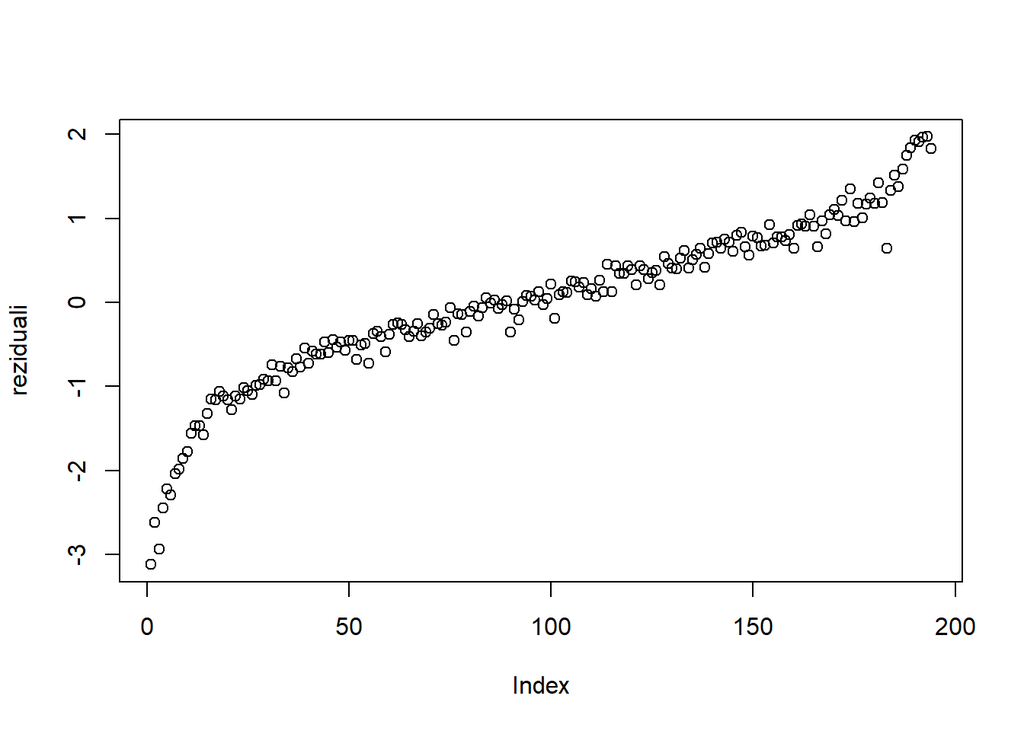

```r
reziduali <- residuals(lmOcjene)


plot(reziduali)
```

A ako uzmemo u obzir samo filmove koji pripadaju u gornjih 33% po Runtimeu, možemo primjetiti blagi pozitivni trend.

Reziduali također imaju srednju vrijednost blizu nule, što je dobro. Srednja vrijednost reziduala blizu nule ukazuje na to da model nije sustavno precijenio ili podcijenio stvarne vrijednosti.

**PETI ZADATAK**

```r
data5 <- data2
score_runtime_language <-data5[,c("IMDB Score","Runtime","Language")]

score_runtime_language$Language[score_runtime_language$Language=="English/Japanese"] <- "Japanese"
score_runtime_language$Language[score_runtime_language$Language=="English/Spanish"] <- "Spanish"
score_runtime_language$Language[score_runtime_language$Language=="Spanish/Basque"] <- "Spanish"
score_runtime_language$Language[score_runtime_language$Language=="Spanish/Catalan"] <- "Spanish"
score_runtime_language$Language[score_runtime_language$Language=="English/Swedish"] <- "Swedish"
score_runtime_language$Language[score_runtime_language$Language=="English/Taiwanese/Mandarin"] <- "English"
score_runtime_language$Language[score_runtime_language$Language=="Thia/English"] <- "English"
score_runtime_language$Language[score_runtime_language$Language=="English/Mandarin"] <- "Mandarin"
score_runtime_language$Language[score_runtime_language$Language=="Khmer/English/French"] <- "French"
score_runtime_language$Language[score_runtime_language$Language=="English/Hindi"] <- "Hindi"
score_runtime_language$Language[score_runtime_language$Language=="Spanish/English"] <- "Spanish"
score_runtime_language$Language[score_runtime_language$Language=="English/Korean"] <- "Korean"
score_runtime_language$Language[score_runtime_language$Language=="English/Arabic"] <- "Arabic"
score_runtime_language$Language[score_runtime_language$Language=="English/Russian"] <- "Russian"
score_runtime_language$Language[score_runtime_language$Language=="English/Akan"] <- "English"
score_runtime_language$Language[score_runtime_language$Language=="English/Ukranian/Russian"] <- "Russian"


jezici_za_sadržavanje <- c("Portuguese", "Italian","French","Hindi","Spanish","English","Indonesian","Japanese","Korean","Turkish")

# Filtrirajte podatke tako da uklonite retke s određenim žanrovima
score_runtime_language_filtered <- score_runtime_language %>% filter(Language %in% jezici_za_sadržavanje)


require(fastDummies)
score_runtime_language_filtered.d <- dummy_cols(score_runtime_language_filtered, select_columns='Language')


lm_score_runtime_lang <- lm(`IMDB Score`~Runtime + Language_English+Language_French+Language_Hindi+Language_Indonesian+Language_Italian+Language_Japanese+Language_Korean+Language_Portuguese+Language_Spanish+Language_Turkish, data=score_runtime_language_filtered.d)
summary(lm_score_runtime_lang)
```

```
##
## Call:
## lm(formula = `IMDB Score` ~ Runtime + Language_English + Language_French +
##     Language_Hindi + Language_Indonesian + Language_Italian +
##     Language_Japanese + Language_Korean + Language_Portuguese +
##     Language_Spanish + Language_Turkish, data = score_runtime_language_filtered.d)
##
## Residuals:
##     Min      1Q  Median      3Q     Max
## -3.7038 -0.5849  0.0859  0.7006  2.6138
##
## Coefficients: (1 not defined because of singularities)
##                       Estimate Std. Error t value Pr(>|t|)
## (Intercept)          5.6804203  0.4560785  12.455   <2e-16 ***
## Runtime             -0.0002006  0.0014979  -0.134   0.8935
## Language_English     0.7224193  0.4327391   1.669   0.0956 .
## Language_French      0.1766834  0.4783903   0.369   0.7120
## Language_Hindi       0.3989940  0.4597188   0.868   0.3858
## Language_Indonesian  0.1848412  0.5361043   0.345   0.7304
## Language_Italian    -0.1178335  0.5007670  -0.235   0.8141
## Language_Japanese    0.2389870  0.5479841   0.436   0.6629
## Language_Korean      0.4572488  0.5632184   0.812   0.4172
## Language_Portuguese  0.5545504  0.5118477   1.083   0.2791
## Language_Spanish     0.6395902  0.4570956   1.399   0.1623
## Language_Turkish            NA         NA      NA       NA
## ---
## Signif. codes:  0 '***' 0.001 '**' 0.01 '*' 0.05 '.' 0.1 ' ' 1
##
## Residual standard error: 0.9611 on 543 degrees of freedom
## Multiple R-squared:  0.04364,    Adjusted R-squared:  0.02602
## F-statistic: 2.478 on 10 and 543 DF,  p-value: 0.006596
```

```r
data5_plusGenre <- data_genre_sep

genre_1_runtime <-data5_plusGenre[,c("Genre_1","Runtime","IMDB Score")]
genre_2_runtime <-data5_plusGenre[,c("Genre_2","Runtime","IMDB Score")]
genre_3_runtime <-data5_plusGenre[,c("Genre_3","Runtime","IMDB Score")]
genre_4_runtime <-data5_plusGenre[,c("Genre_4","Runtime","IMDB Score")]

colnames(genre_1_runtime)[1] <- "Genre"
colnames(genre_2_runtime)[1] <- "Genre"
colnames(genre_3_runtime)[1] <- "Genre"
colnames(genre_4_runtime)[1] <- "Genre"

genre_runtime <- rbind(genre_1_runtime,genre_2_runtime,genre_3_runtime,genre_4_runtime)
genre_runtime$Genre <- str_trim(genre_runtime$Genre)

genre_runtime$Genre[genre_runtime$Genre=="Musicial"] <- "Musical"
genre_runtime$Genre[genre_runtime$Genre=="Action thriller"] <- "Action-thriller"
genre_runtime$Genre[genre_runtime$Genre=="Heist film"] <- "Heist"
genre_runtime$Genre[genre_runtime$Genre=="Romance drama"] <- "Romantic drama"
genre_runtime$Genre[genre_runtime$Genre=="Romantic teen drama"] <- "Romantic teenage drama"
genre_runtime$Genre[genre_runtime$Genre=="Science Fiction"] <- "Science fiction"
genre_runtime$Genre[genre_runtime$Genre %in% c("Action","Action comedy","Action-adventure","Action-thriller")] <- "Action"
genre_runtime$Genre[genre_runtime$Genre %in% c("Adventure","Adventure-romance")] <- "Adventure"
genre_runtime$Genre[genre_runtime$Genre %in% c("Animated musical comedy","Animation")] <- "Animation"
genre_runtime$Genre[genre_runtime$Genre %in% c("Black comedy","Comedy","Comedy horror","Comedy mystery","Comedy-drama","Coming-of-age comedy-drama","Dark comedy","Dance comedy")] <- "Comedy"
genre_runtime$Genre[genre_runtime$Genre %in% c("Christian musical","Christmas","Christmas comedy","Christmas musical")] <- "Christmas"
genre_runtime$Genre[genre_runtime$Genre %in% c("Crime drama","Crime thriller")] <- "Crime"
genre_runtime$Genre[genre_runtime$Genre %in% c("Drama","Drama-Comedy","Supernatural drama")] <- "Drama"
genre_runtime$Genre[genre_runtime$Genre %in% c("Family","Family film")] <- "Family"
genre_runtime$Genre[genre_runtime$Genre %in% c("Historical drama","Historical-epic")] <- "Historical"
genre_runtime$Genre[genre_runtime$Genre %in% c("Horror-thriller","Horror thriller","Horror comedy","Horror anthology","Horror")] <- "Horror"
genre_runtime$Genre[genre_runtime$Genre %in% c("Musical","Musical comedy")] <- "Musical"
genre_runtime$Genre[genre_runtime$Genre %in% c("Political thriller","Psychological thriller","Psychological thriller drama")] <- "Psychological"
genre_runtime$Genre[genre_runtime$Genre %in% c("Romantic comedy","Romantic comedy-drama","Romantic drama","Romance","Romantic teenage drama","Romantic thriller")] <- "Romance"
genre_runtime$Genre[genre_runtime$Genre %in% c("Science fiction adventure","Science fiction thriller")] <- "Science fiction"
genre_runtime$Genre[genre_runtime$Genre %in% c("Sports film","Sports-drama")] <- "Sports"
genre_runtime$Genre[genre_runtime$Genre %in% c("Spy thriller","Thriller")] <- "Thriller"
genre_runtime$Genre[genre_runtime$Genre %in% c("Superhero","Superhero-Comedy")] <- "Superhero"
genre_runtime$Genre[genre_runtime$Genre %in% c("Teen comedy horror","Teen comedy-drama")] <- "Teen"
genre_runtime$Genre[genre_runtime$Genre %in% c("Variety Show","Variety show")] <- "Variety"
genre_runtime$Genre[genre_runtime$Genre %in% c("War","War drama","War-Comedy")] <- "War"

genre_runtime <- na.omit(genre_runtime)




# Primjena "one-hot encoding" na varijablu 'Genre'
score_runtime_genre_d <- dummy_cols(genre_runtime, select_columns='Genre', remove_first_dummy = TRUE)
score_runtime_genre_d_dobar <- score_runtime_genre_d[-1]

# Stvaranje linearnog modela
lm_score_runtime_genre <- lm(`IMDB Score` ~ Runtime + ., data=score_runtime_genre_d_dobar)

# Prikazivanje rezultata modela
summary(lm_score_runtime_genre)
```

```
##
## Call:
## lm(formula = `IMDB Score` ~ Runtime + ., data = score_runtime_genre_d_dobar)
##
## Residuals:
##     Min      1Q  Median      3Q     Max
## -4.2636 -0.3891  0.0323  0.5065  2.3806
##
## Coefficients:
##                                     Estimate Std. Error t value Pr(>|t|)
## (Intercept)                         4.865386   0.245067  19.853  < 2e-16 ***
## Runtime                             0.008246   0.001518   5.433 8.06e-08 ***
## Genre_Adventure                     0.889634   0.347224   2.562  0.01065 *
## Genre_Aftershow                     1.689456   0.406793   4.153 3.76e-05 ***
## Genre_Animation                     1.427229   0.283442   5.035 6.32e-07 ***
## Genre_Anime                         0.690895   0.458272   1.508  0.13218
## Genre_Anthology                     1.505945   0.855862   1.760  0.07899 .
## Genre_Biographical                  1.101758   0.853682   1.291  0.19734
## Genre_Biopic                        0.647700   0.332270   1.949  0.05172 .
## Genre_Christmas                     0.702107   0.386090   1.819  0.06949 .
## Genre_Comedy                        0.154108   0.204292   0.754  0.45094
## `Genre_Concert Film`                1.954332   0.386329   5.059 5.62e-07 ***
## Genre_Crime                         0.867676   0.294475   2.947  0.00334 **
## Genre_Documentary                   1.419961   0.198636   7.149 2.57e-12 ***
## Genre_Drama                         0.545283   0.203519   2.679  0.00758 **
## Genre_Family                        0.160378   0.364029   0.441  0.65969
## Genre_Fantasy                       0.111234   0.415482   0.268  0.78900
## Genre_Heist                        -1.148374   0.515950  -2.226  0.02640 *
## `Genre_Hidden-camera prank comedy`  1.025449   0.854274   1.200  0.23047
## Genre_Historical                    1.108498   0.618093   1.793  0.07341 .
## Genre_Holiday                       0.377020   0.853636   0.442  0.65889
## Genre_Horror                       -0.337144   0.264198  -1.276  0.20241
## Genre_Interview                     1.689456   0.406793   4.153 3.76e-05 ***
## `Genre_Making-of`                   2.234155   0.625150   3.574  0.00038 ***
## `Genre_Mentalism special`           1.830555   0.858319   2.133  0.03335 *
## Genre_Mockumentary                  0.460987   0.620869   0.742  0.45808
## Genre_Musical                       0.603892   0.323742   1.865  0.06262 .
## Genre_Mystery                      -0.819883   0.514748  -1.593  0.11174
## `Genre_One-man show`                1.454332   0.514949   2.824  0.00490 **
## Genre_Psychological                 0.066395   0.386959   0.172  0.86382
## `Genre_Psychological horror`        0.259481   0.853883   0.304  0.76132
## Genre_Romance                       0.193180   0.213634   0.904  0.36622
## Genre_Satire                        0.134742   0.617393   0.218  0.82731
## `Genre_Science fiction`             0.110383   0.264400   0.417  0.67647
## Genre_Short                         1.812979   0.392544   4.619 4.73e-06 ***
## Genre_Sports                        0.418250   0.455189   0.919  0.35854
## `Genre_Stop Motion`                 0.988278   0.859495   1.150  0.25067
## Genre_Superhero                    -0.401122   0.415014  -0.967  0.33417
## Genre_Teen                          0.084219   0.617709   0.136  0.89160
## Genre_Thriller                     -0.125323   0.224770  -0.558  0.57735
## `Genre_Urban fantasy`               0.469820   0.853719   0.550  0.58230
## Genre_Variety                       0.746445   0.421598   1.771  0.07715 .
## Genre_War                           0.829009   0.415968   1.993  0.04672 *
## Genre_Western                      -0.212411   0.454992  -0.467  0.64078
## Genre_Zombie                       -0.185809   0.855754  -0.217  0.82818
## ---
## Signif. codes:  0 '***' 0.001 '**' 0.01 '*' 0.05 '.' 0.1 ' ' 1
##
## Residual standard error: 0.834 on 598 degrees of freedom
## Multiple R-squared:  0.3412, Adjusted R-squared:  0.2927
## F-statistic: 7.038 on 44 and 598 DF,  p-value: < 2.2e-16
```

```r
score_runtime_genre_d_no_runtime <- score_runtime_genre_d[-1]
score_runtime_genre_d_no_runtime <- score_runtime_genre_d_no_runtime[-1]
lm_score_genre <- lm(`IMDB Score` ~ . , data=score_runtime_genre_d_no_runtime)

# Prikazivanje rezultata modela
summary(lm_score_genre)
```

```
##
## Call:
## lm(formula = `IMDB Score` ~ ., data = score_runtime_genre_d_no_runtime)
##
## Residuals:
##     Min      1Q  Median      3Q     Max
## -4.4365 -0.3982  0.0214  0.5214  2.3881
##
## Coefficients:
##                                     Estimate Std. Error t value Pr(>|t|)
## (Intercept)                         5.757143   0.186273  30.907  < 2e-16 ***
## Genre_Adventure                     0.767857   0.354654   2.165 0.030775 *
## Genre_Aftershow                     0.992857   0.395145   2.513 0.012245 *
## Genre_Animation                     0.995798   0.278495   3.576 0.000378 ***
## Genre_Anime                         0.392857   0.465683   0.844 0.399222
## Genre_Anthology                     1.842857   0.873699   2.109 0.035337 *
## Genre_Biographical                  1.042857   0.873699   1.194 0.233103
## Genre_Biopic                        0.642857   0.340087   1.890 0.059204 .
## Genre_Christmas                     0.676190   0.395145   1.711 0.087554 .
## Genre_Comedy                        0.054762   0.208260   0.263 0.792680
## `Genre_Concert Film`                1.876190   0.395145   4.748 2.57e-06 ***
## Genre_Crime                         0.919780   0.301244   3.053 0.002364 **
## Genre_Documentary                   1.179335   0.198193   5.950 4.55e-09 ***
## Genre_Drama                         0.521429   0.208260   2.504 0.012554 *
## Genre_Family                        0.128571   0.372547   0.345 0.730129
## Genre_Fantasy                       0.002857   0.424768   0.007 0.994635
## Genre_Heist                        -0.957143   0.526860  -1.817 0.069764 .
## `Genre_Hidden-camera prank comedy`  0.842857   0.873699   0.965 0.335085
## Genre_Historical                    1.292857   0.631683   2.047 0.041125 *
## Genre_Holiday                       0.342857   0.873699   0.392 0.694887
## Genre_Horror                       -0.383459   0.270274  -1.419 0.156484
## Genre_Interview                     0.992857   0.395145   2.513 0.012245 *
## `Genre_Making-of`                   1.692857   0.631683   2.680 0.007567 **
## `Genre_Mentalism special`           1.342857   0.873699   1.537 0.124827
## Genre_Mockumentary                  0.092857   0.631683   0.147 0.883182
## Genre_Musical                       0.352857   0.327968   1.076 0.282410
## Genre_Mystery                      -0.823810   0.526860  -1.564 0.118435
## `Genre_One-man show`                1.376190   0.526860   2.612 0.009226 **
## Genre_Psychological                 0.209524   0.395145   0.530 0.596139
## `Genre_Psychological horror`        0.142857   0.873699   0.164 0.870173
## Genre_Romance                       0.139286   0.218425   0.638 0.523924
## Genre_Satire                        0.042857   0.631683   0.068 0.945931
## `Genre_Science fiction`             0.037594   0.270274   0.139 0.889421
## Genre_Short                         1.014286   0.372547   2.723 0.006666 **
## Genre_Sports                        0.342857   0.465683   0.736 0.461870
## `Genre_Stop Motion`                 0.442857   0.873699   0.507 0.612428
## Genre_Superhero                    -0.417143   0.424768  -0.982 0.326473
## Genre_Teen                         -0.057143   0.631683  -0.090 0.927951
## Genre_Thriller                     -0.144643   0.230031  -0.629 0.529721
## `Genre_Urban fantasy`               0.542857   0.873699   0.621 0.534618
## Genre_Variety                       0.342857   0.424768   0.807 0.419893
## Genre_War                           0.982857   0.424768   2.314 0.021013 *
## Genre_Western                      -0.232143   0.465683  -0.498 0.618315
## Genre_Zombie                        0.142857   0.873699   0.164 0.870173
## ---
## Signif. codes:  0 '***' 0.001 '**' 0.01 '*' 0.05 '.' 0.1 ' ' 1
##
## Residual standard error: 0.8536 on 599 degrees of freedom
## Multiple R-squared:  0.3087, Adjusted R-squared:  0.259
## F-statistic: 6.219 on 43 and 599 DF,  p-value: < 2.2e-16
```

R² ovdje objašnjava čak 34% varijance i to potvrđuje jako mala p-vrijednost te nas upućuje na to da kombinacija Duljine i Žanra filma i značajan utjecaj na ocjenu. U slučaju kada razmatramo samo utjecaj žanrova na score, tad je jasno da samo 30% varijance je objašnjeno u našem testu.

```r
data5_plusGenre_plusPremiere <- data_genre_sep

genre_1_runtime <-data5_plusGenre_plusPremiere[,c("Genre_1","Premiere","IMDB Score")]
genre_2_runtime <-data5_plusGenre_plusPremiere[,c("Genre_2","Premiere","IMDB Score")]
genre_3_runtime <-data5_plusGenre_plusPremiere[,c("Genre_3","Premiere","IMDB Score")]
genre_4_runtime <-data5_plusGenre_plusPremiere[,c("Genre_4","Premiere","IMDB Score")]

colnames(genre_1_runtime)[1] <- "Genre"
colnames(genre_2_runtime)[1] <- "Genre"
colnames(genre_3_runtime)[1] <- "Genre"
colnames(genre_4_runtime)[1] <- "Genre"

genre_score_premiere <- rbind(genre_1_runtime,genre_2_runtime,genre_3_runtime,genre_4_runtime)
genre_score_premiere$Genre <- str_trim(genre_score_premiere$Genre)

genre_score_premiere$Genre[genre_score_premiere$Genre=="Musicial"] <- "Musical"
genre_score_premiere$Genre[genre_score_premiere$Genre=="Action thriller"] <- "Action-thriller"
genre_score_premiere$Genre[genre_score_premiere$Genre=="Heist film"] <- "Heist"
genre_score_premiere$Genre[genre_score_premiere$Genre=="Romance drama"] <- "Romantic drama"
genre_score_premiere$Genre[genre_score_premiere$Genre=="Romantic teen drama"] <- "Romantic teenage drama"
genre_score_premiere$Genre[genre_score_premiere$Genre=="Science Fiction"] <- "Science fiction"
genre_score_premiere$Genre[genre_score_premiere$Genre %in% c("Action","Action comedy","Action-adventure","Action-thriller")] <- "Action"
genre_score_premiere$Genre[genre_score_premiere$Genre %in% c("Adventure","Adventure-romance")] <- "Adventure"
genre_score_premiere$Genre[genre_score_premiere$Genre %in% c("Animated musical comedy","Animation")] <- "Animation"
genre_score_premiere$Genre[genre_score_premiere$Genre %in% c("Black comedy","Comedy","Comedy horror","Comedy mystery","Comedy-drama","Coming-of-age comedy-drama","Dark comedy","Dance comedy")] <- "Comedy"
genre_score_premiere$Genre[genre_score_premiere$Genre %in% c("Christian musical","Christmas","Christmas comedy","Christmas musical")] <- "Christmas"
genre_score_premiere$Genre[genre_score_premiere$Genre %in% c("Crime drama","Crime thriller")] <- "Crime"
genre_score_premiere$Genre[genre_score_premiere$Genre %in% c("Drama","Drama-Comedy","Supernatural drama")] <- "Drama"
genre_score_premiere$Genre[genre_score_premiere$Genre %in% c("Family","Family film")] <- "Family"
genre_score_premiere$Genre[genre_score_premiere$Genre %in% c("Historical drama","Historical-epic")] <- "Historical"
genre_score_premiere$Genre[genre_score_premiere$Genre %in% c("Horror-thriller","Horror thriller","Horror comedy","Horror anthology","Horror")] <- "Horror"
genre_score_premiere$Genre[genre_score_premiere$Genre %in% c("Musical","Musical comedy")] <- "Musical"
genre_score_premiere$Genre[genre_score_premiere$Genre %in% c("Political thriller","Psychological thriller","Psychological thriller drama")] <- "Psychological"
genre_score_premiere$Genre[genre_score_premiere$Genre %in% c("Romantic comedy","Romantic comedy-drama","Romantic drama","Romance","Romantic teenage drama","Romantic thriller")] <- "Romance"
genre_score_premiere$Genre[genre_score_premiere$Genre %in% c("Science fiction adventure","Science fiction thriller")] <- "Science fiction"
genre_score_premiere$Genre[genre_score_premiere$Genre %in% c("Sports film","Sports-drama")] <- "Sports"
genre_score_premiere$Genre[genre_score_premiere$Genre %in% c("Spy thriller","Thriller")] <- "Thriller"
genre_score_premiere$Genre[genre_score_premiere$Genre %in% c("Superhero","Superhero-Comedy")] <- "Superhero"
genre_score_premiere$Genre[genre_score_premiere$Genre %in% c("Teen comedy horror","Teen comedy-drama")] <- "Teen"
genre_score_premiere$Genre[genre_score_premiere$Genre %in% c("Variety Show","Variety show")] <- "Variety"
genre_score_premiere$Genre[genre_score_premiere$Genre %in% c("War","War drama","War-Comedy")] <- "War"

genre_score_premiere <- na.omit(genre_score_premiere)

genre_score_premiere$Year <- sub(".*?(\\d{4}).*", "\\1", genre_score_premiere$Premiere)
genre_score_premiere$Year <- as.numeric(genre_score_premiere$Year)
genre_score_premiere <- genre_score_premiere[-2]




# Primjena "one-hot encoding" na varijablu 'Genre'
score_year_genre_d <- dummy_cols(genre_score_premiere, select_columns='Genre', remove_first_dummy = TRUE)

# Stvaranje linearnog modela
lm_score_year_genre <- lm(`IMDB Score` ~ Year + ., data=score_year_genre_d)

# Prikazivanje rezultata modela
summary(lm_score_year_genre)
```

```
##
## Call:
## lm(formula = `IMDB Score` ~ Year + ., data = score_year_genre_d)
##
## Residuals:
##     Min      1Q  Median      3Q     Max
## -4.4113 -0.4113  0.0289  0.5168  2.4009
##
## Coefficients: (43 not defined because of singularities)
##                                      Estimate Std. Error t value Pr(>|t|)
## (Intercept)                         1.265e+02  4.958e+01   2.551 0.010974 *
## Year                               -5.981e-02  2.456e-02  -2.435 0.015167 *
## GenreAdventure                      7.550e-01  3.532e-01   2.137 0.032966 *
## GenreAftershow                      1.020e+00  3.937e-01   2.591 0.009812 **
## GenreAnimation                      1.055e+00  2.784e-01   3.790 0.000166 ***
## GenreAnime                          4.249e-01  4.640e-01   0.916 0.360140
## GenreAnthology                      1.920e+00  8.707e-01   2.205 0.027844 *
## GenreBiographical                   1.000e+00  8.703e-01   1.149 0.250941
## GenreBiopic                         6.400e-01  3.387e-01   1.890 0.059293 .
## GenreChristmas                      7.332e-01  3.942e-01   1.860 0.063412 .
## GenreComedy                         5.903e-02  2.074e-01   0.285 0.776035
## GenreConcert Film                   1.863e+00  3.936e-01   4.735 2.74e-06 ***
## GenreCrime                          9.369e-01  3.001e-01   3.122 0.001883 **
## GenreDocumentary                    1.171e+00  1.974e-01   5.933 5.04e-09 ***
## GenreDrama                          5.627e-01  2.081e-01   2.704 0.007043 **
## GenreFamily                         1.884e-01  3.718e-01   0.507 0.612597
## GenreFantasy                        3.191e-02  4.232e-01   0.075 0.939922
## GenreHeist                         -9.201e-01  5.249e-01  -1.753 0.080140 .
## GenreHidden-camera prank comedy     9.796e-01  8.719e-01   1.123 0.261698
## GenreHistorical                     1.280e+00  6.291e-01   2.035 0.042327 *
## GenreHoliday                        4.198e-01  8.707e-01   0.482 0.629914
## GenreHorror                        -3.727e-01  2.692e-01  -1.384 0.166777
## GenreInterview                      1.020e+00  3.937e-01   2.591 0.009812 **
## GenreMaking-of                      1.740e+00  6.294e-01   2.764 0.005880 **
## GenreMentalism special              1.300e+00  8.703e-01   1.494 0.135732
## GenreMockumentary                   2.023e-02  6.298e-01   0.032 0.974390
## GenreMusical                        3.520e-01  3.266e-01   1.078 0.281606
## GenreMystery                       -8.067e-01  5.248e-01  -1.537 0.124740
## GenreOne-man show                   1.314e+00  5.253e-01   2.500 0.012673 *
## GenrePsychological                  2.864e-01  3.948e-01   0.726 0.468424
```

[output cut: 49 more lines]

```
## `Genre_Stop Motion`                        NA         NA      NA       NA
## Genre_Superhero                            NA         NA      NA       NA
## Genre_Teen                                 NA         NA      NA       NA
## Genre_Thriller                             NA         NA      NA       NA
## `Genre_Urban fantasy`                      NA         NA      NA       NA
## Genre_Variety                              NA         NA      NA       NA
## Genre_War                                  NA         NA      NA       NA
## Genre_Western                              NA         NA      NA       NA
## Genre_Zombie                               NA         NA      NA       NA
## ---
## Signif. codes:  0 '***' 0.001 '**' 0.01 '*' 0.05 '.' 0.1 ' ' 1
##
## Residual standard error: 0.8501 on 598 degrees of freedom
## Multiple R-squared:  0.3154, Adjusted R-squared:  0.2651
## F-statistic: 6.263 on 44 and 598 DF,  p-value: < 2.2e-16
```